# SOMSerraDourada

Paper: Unveiling Geological Complexity in the Serra Dourada Granite Using Self-Organizing Maps and Hierarchical Clustering: Insights for REE Prospecting in the Goiás Tin Province, Central Brazil

Authors: Ferreira da Silva, G.; Ferreira, M.V., Chemale, L.T.; Santana, I.V.; Botelho, N.F. 2024.

Abstract: This study explores the use of Self-Organizing Maps (SOM) combined with hierarchical clustering to provide insights into the geological differentiation and mineral prospecting in the Serra Dourada Granite (SDG), part of the Goiás Tin Province. After some issues on the geological cartography of the SDG based on traditional approaches, such as the interpretation of outcrops and the limited geochemistry data, often struggle to capture the complexity of high-dimensional geophysical datasets. To address this, we apply unsupervised machine learning techniques to segment airborne geophysical data, providing a more nuanced understanding of the SDG internal structure. Using airborne gamma-ray data, we employed SOM for dimensionality reduction and data segmentation, supported by hierarchical clustering. This methodology enabled us to identify distinct geological units with greater accuracy and resolution than traditional methods such as Principal Component Analysis (PCA). The SOM-based approach retained the data’s original topology and revealed fine-scale patterns within the dataset, distinguishing between areas affected by magmatic processes and those influenced by post-magmatic hydrothermalism and supergene leaching. The results indicate that some clusters are mainly associated with magmatic differentiation, characterized by average concentrations of potassium (K), equivalent thorium (eTh), and equivalent uranium (eU) and others show evidence of secondary processes, including hydrothermal alteration and weathering. Notably, Cluster 4 is spatially linked to REE-enriched plateaus and the Serra Verde Mine, reinforcing its significance for mineral exploration. The SOM model proved more effective than PCA at capturing non-linear relationships within the data. While PCA provided insights into the primary variance, it did not fully account for the complex geological processes at play. In contrast, the SOM model segmented the data into clusters that reflected both broad geophysical trends and localized variations, particularly in areas influenced by hydrothermalism and supergene processes. Our findings underscore the value of machine learning techniques, particularly SOM, in geoscientific data analysis. This approach provides a robust framework for integrating multivariate geophysical data, offering valuable insights for geological mapping and mineral exploration, especially in regions with complex geological histories. The methodology presented here can be adapted to other geological settings, enhancing the accuracy of subsurface mapping and identifying areas of economic interest, such as Rare Earth Element (REE) and other critical mineral deposits.

Keywords: Unsupervised Segmentation; Compositional Data Analysis; Clustering Algorithms; Machine Learning Applications in Geoscience; Dimensionality Reduction

```r
# Setting up the enviroment
setwd('~/GitHub/GoiasTinProvince/data') # Working direction
set.seed(0) # Random State
```

Predifined Functions

```r
# Color Pallette
coolBlueHotRed <- function(n, alpha = 1) {
  rainbow(n, end=4/6, alpha=alpha)[n:1]
}

# Traning SOM for iterations
training_som <- function(xdim = 10,ydim = 15,rlen = 100,k = 8){
  som_grid <- kohonen::somgrid(xdim = xdim,ydim = ydim,
                               topo = 'hexagonal',
                               toroidal = TRUE,
                               neighbourhood.fct = 'gaussian')
  set.seed(0)
  print(paste('xdim: ',xdim,', ydim: ',ydim,' rlen: ',rlen,' Time: ',system.time(som_model <- kohonen::som(data_train,
                                                                                                           grid = som_grid,
                                                                                                           rlen = rlen,
                                                                                                           keep.data = TRUE))[3]
  ))

  mydata <- kohonen::getCodes(som_model) # Assigning data to closest neuron
  cut_avg <- cutree(hclust(dist(mydata), method = 'average'), k = k)

  cluster_assignment <- cut_avg[som_model$unit.classif]

  df$hc_avg <- cluster_assignment

  (p1 <- ggplot(df, aes(x = Longitude,
                       y = Latitude,
                       fill = as.factor(hc_avg))) +
    geom_raster() +
    coord_equal() +
    scale_fill_viridis_d(option = 'B') +
    theme_classic() +
    labs(title = paste0('xdim: ',xdim,', ydim: ',ydim,', rlen: ',rlen,' and k: ',k),
         fill = 'Cluster') +
    theme(axis.text.x = element_text(angle = 90,
                                     vjust = .5))
    )
  ggsave(filename = paste('figure/som',xdim,ydim,rlen,'.pdf',sep = '_'),width = 8,height = 8,device = 'pdf',plot = p1)
}

# Radar plot
coord_radar <- function (theta = "x", start = 0, direction = 1) {
  theta <- match.arg(theta, c("x", "y"))
  r <- if (theta == "x") "y" else "x"
  ggproto("CordRadar", CoordPolar, theta = theta, r = r, start = start,
          direction = sign(direction),
          is_linear = function(coord) TRUE)
}
```

Importing libraries

```r
library(tidyverse) # ggplot, dplyr, readr, tibble, readr
library(factoextra) # Cluster Vis and PCA
library(geoquimica) # Data transformation
library(kohonen) # Self Organizing Maps
library(doParallel) # Parallel Computing
library(foreach) # For loops
library(circlize) # Data vis
library(ggpubr) # Data vis
library(dendextend) # Dendograms and HClustering
library(pheatmap) # Dissimilarity matrix
```

Importing and previewing data:

```r
df_raw <- readRDS('~/GitHub/GoiasTinProvince/data/gamma_GSD.RDS') %>%
  filter(!is.na(X)) %>%
  select(c('X','Y','KPERC','eTH','eU','CT')) %>%
  rename(Longitude = X,
         Latitude = Y,
         TC = CT,
         K = KPERC) %>%
  mutate(Ki = eTH*(mean(K, na.rm = TRUE)/mean(eTH, na.rm = TRUE)),
         Ui = eTH*mean(eU, na.rm = TRUE)/mean(eTH, na.rm = TRUE)) %>%
  mutate(Kd = K - Ki,
         Ud = eU - Ui,
         K_TH = K/eTH
  )

head(df_raw)
```

| Longitude | Latitude | K | eTH | eU | TC | Ki | Ui | Kd | Ud | K_TH |
| --- | --- | --- | --- | --- | --- | --- | --- | --- | --- | --- |
| -48.49275 | -13.57551 | 1.585320 | 37.14201 | 3.180177 | 15.16076 | 1.885156 | 2.802171 | -0.2998354 | 0.37800656 | 0.04268267 |
| -48.49152 | -13.57551 | 1.639656 | 39.07323 | 3.394328 | 15.97142 | 1.983176 | 2.947871 | -0.3435193 | 0.44645693 | 0.04196367 |
| -48.49029 | -13.57551 | 1.697323 | 40.15634 | 3.482608 | 16.42931 | 2.038149 | 3.029586 | -0.3408263 | 0.45302194 | 0.04226787 |
| -48.48906 | -13.57551 | 1.747037 | 40.76690 | 3.468431 | 16.66500 | 2.069138 | 3.075649 | -0.3221012 | 0.39278219 | 0.04285430 |
| -48.48783 | -13.57551 | 1.775707 | 41.19197 | 3.378610 | 16.76237 | 2.090713 | 3.107719 | -0.3150061 | 0.27089136 | 0.04310808 |
| -48.48660 | -13.57551 | 1.774680 | 41.54077 | 3.233844 | 16.75653 | 2.108416 | 3.134034 | -0.3337361 | 0.09981013 | 0.04272141 |

Data Preparation:

```r
# Processing ----

# Min-max feature scaling
df_norm <- df_raw %>%
  elem_norm(method = 'minmax',
            keep = c('Longitude', 'Latitude')) %>%
  select(-Ki,-Ui,-TC)

summary(df_norm)
```

```
   Longitude         Latitude            K
 Min.   :-48.58   Min.   :-13.58   Min.   :0.0000
 1st Qu.:-48.53   1st Qu.:-13.48   1st Qu.:0.2789
 Median :-48.51   Median :-13.34   Median :0.4022
 Mean   :-48.51   Mean   :-13.34   Mean   :0.4128
 3rd Qu.:-48.49   3rd Qu.:-13.21   3rd Qu.:0.5411
 Max.   :-48.43   Max.   :-13.07   Max.   :1.0000
      eTH               eU               Kd
 Min.   :0.0000   Min.   :0.0000   Min.   :0.0000
 1st Qu.:0.1762   1st Qu.:0.2090   1st Qu.:0.6451
 Median :0.2626   Median :0.2846   Median :0.7208
 Mean   :0.2769   Mean   :0.3053   Mean   :0.7030
 3rd Qu.:0.3405   3rd Qu.:0.3828   3rd Qu.:0.7766
 Max.   :1.0000   Max.   :1.0000   Max.   :1.0000
       Ud              K_TH
 Min.   :0.0000   Min.   :0.0000
 1st Qu.:0.6111   1st Qu.:0.1102
 Median :0.6711   Median :0.1608
 Mean   :0.6654   Mean   :0.1786
 3rd Qu.:0.7272   3rd Qu.:0.2219
 Max.   :1.0000   Max.   :1.0000
```

```r
# CLR transformation
df_clr <- df_raw %>%
  elem_norm(method = 'clr',
            keep = c('Longitude', 'Latitude','Kd','Ud')) %>%
  elem_norm(method = 'minmax', keep = c('Longitude', 'Latitude')) %>%
  dplyr::select(-Ki,-Ui,-TC)

summary(df_clr)
```

```
   Longitude         Latitude            K
 Min.   :-48.58   Min.   :-13.58   Min.   :0.0000
 1st Qu.:-48.53   1st Qu.:-13.48   1st Qu.:0.5902
 Median :-48.51   Median :-13.34   Median :0.7009
 Mean   :-48.51   Mean   :-13.34   Mean   :0.6827
 3rd Qu.:-48.49   3rd Qu.:-13.21   3rd Qu.:0.7953
 Max.   :-48.43   Max.   :-13.07   Max.   :1.0000
      eTH               eU               Kd
 Min.   :0.0000   Min.   :0.0000   Min.   :0.0000
 1st Qu.:0.5603   1st Qu.:0.6916   1st Qu.:0.6451
 Median :0.6567   Median :0.7518   Median :0.7208
 Mean   :0.6317   Mean   :0.7451   Mean   :0.7030
 3rd Qu.:0.7214   3rd Qu.:0.8099   3rd Qu.:0.7766
 Max.   :1.0000   Max.   :1.0000   Max.   :1.0000
       Ud              K_TH
 Min.   :0.0000   Min.   :0.0000
 1st Qu.:0.6111   1st Qu.:0.4570
 Median :0.6711   Median :0.5424
 Mean   :0.6654   Mean   :0.5385
 3rd Qu.:0.7272   3rd Qu.:0.6186
 Max.   :1.0000   Max.   :1.0000
```

Principal Components Analysis

```r
# PCA
pca <- prcomp(x = df_clr[3:8],center = TRUE,scale. = TRUE)

summary(pca)
```

```
Importance of components:
                          PC1    PC2    PC3     PC4
Standard deviation     1.8251 1.2498 0.9913 0.31667
Proportion of Variance 0.5552 0.2603 0.1638 0.01671
Cumulative Proportion  0.5552 0.8155 0.9793 0.99600
                         PC5       PC6
Standard deviation     0.155 3.652e-15
Proportion of Variance 0.004 0.000e+00
Cumulative Proportion  1.000 1.000e+00
```

```r
df <- bind_cols(df_clr, as_tibble(pca$x[,1:6])) # apending results
```

View Features:

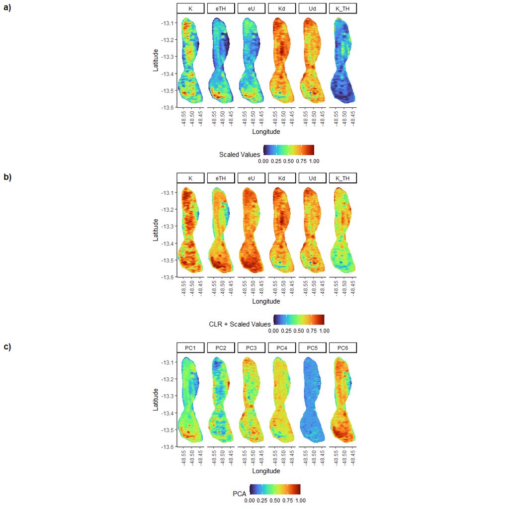

```r
# Plot Feature Maps ----
## Min-Max
raw.plot <- ggplot(df_norm %>%
                      gather(key = 'Variables',value = 'Value', 3:8) %>%
                      mutate(Variables = factor(Variables,levels = c('K',
                                                                     'eTH',
                                                                     'eU',
                                                                     'Kd',
                                                                     'Ud',
                                                                     'K_TH'
                      ))),
                    aes(x = Longitude, y = Latitude, fill = Value)) +
   geom_raster() +
   coord_equal() +
   scale_fill_gradientn(colors = pals::turbo(8)) +
   facet_wrap(. ~ Variables,nrow = 1) +
   theme_classic() +
   theme(axis.text.x = element_text(
     angle = 90,
     vjust = 0.5),
     legend.direction = 'horizontal',
     legend.position = 'bottom')  +
   labs(fill = 'Scaled Values')

## CLR
clr.plot <- ggplot(df_clr %>%
                      gather(key = 'Variables',value = 'Value', 3:8) %>%
                      mutate(Variables = factor(Variables,levels = c('K',
                                                                     'eTH',
                                                                     'eU',
                                                                     'Kd',
                                                                     'Ud',
                                                                     'K_TH'
                      ))),
                    aes(x = Longitude, y = Latitude, fill = Value)) +
    geom_raster() +
    coord_equal() +
    scale_fill_gradientn(colors = pals::turbo(8)) +
    facet_wrap(. ~ Variables,nrow = 1) +
    theme_classic() +
    theme(axis.text.x = element_text(
      angle = 90,
      vjust = 0.5),
      legend.direction = 'horizontal',
      legend.position = 'bottom')   +
    labs(fill = 'CLR + Scaled Values')

## Principal Components maps
pca.plot <- ggplot(df %>%
                      geoquimica::elem_norm(keep = c('Longitude', 'Latitude')) %>%
                      gather(key = 'Components',value = 'PCA', 9:14),
                    aes(x = Longitude, y = Latitude, fill = PCA)) +
    geom_raster() +
    coord_equal() +
    scale_fill_gradientn(colors = pals::turbo(8)) +
    # scale_fill_viridis_c() +
    facet_wrap(. ~ Components,nrow = 1) +
    theme_classic() +
    theme(axis.text.x = element_text(angle = 90,vjust = 0.5),
          legend.direction = 'horizontal',legend.position = 'bottom')

ggarrange(raw.plot,clr.plot,pca.plot,ncol = 1,labels = c('a)','b)','c)'))
```

View PCA Matrix

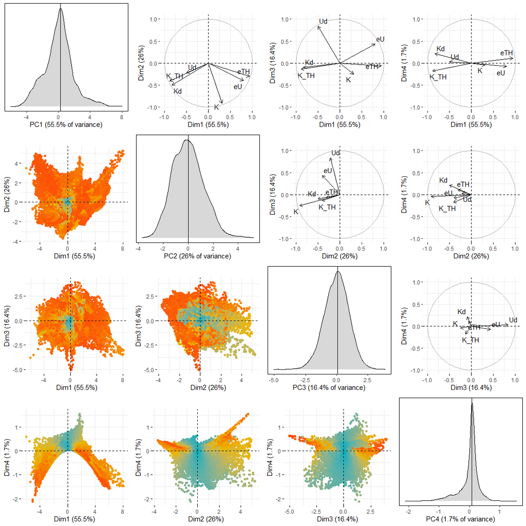

```r
p1 <-
  pca$x %>%
  as_tibble() %>%
  ggplot(aes(x = PC1)) +
  geom_density(alpha = .6, fill = 'grey') +
  geom_vline(xintercept = 0.25) +
  labs(x = paste0('PC1 (',round(100*data.frame(summary(pca)[6])[2,1],1),'% of variance)')) +
  theme(axis.text.y = element_blank(),
        axis.title.y = element_blank(),
        axis.ticks.y = element_blank(),
        panel.grid.major.y = element_blank(),
        panel.grid.minor.y = element_blank(),
        panel.background = element_blank(),
        panel.border = element_rect(fill = NA))

p2 <-
  fviz_pca_var(pca,
             gradient.cols = c("#00AFBB", "#E7B800", "#FC4E07"),
             axes = c(1,2), #controla quais eixos devem ser mostrados na figura
             repel = TRUE     # Avoid text overlapping
) +
  labs(title = '')

p3 <-
  fviz_pca_var(pca,
               gradient.cols = c("#00AFBB", "#E7B800", "#FC4E07"),
               axes = c(1,3), #controla quais eixos devem ser mostrados na figura
               repel = TRUE     # Avoid text overlapping
  ) +
  labs(title = '')

p4 <-
  fviz_pca_var(pca,
               gradient.cols = c("#00AFBB", "#E7B800", "#FC4E07"),
               axes = c(1,4), #controla quais eixos devem ser mostrados na figura
               repel = TRUE     # Avoid text overlapping
  ) +
  labs(title = '')

p5 <-
  fviz_pca_ind(pca,
             col.ind = "cos2", # Color by the quality of representation
             gradient.cols = c("#00AFBB", "#E7B800", "#FC4E07"),
             repel = F,      # Avoid text overlapping
             axes = c(1,2), #controla quais eixos devem ser mostrados na figura
             geom = c("point")
) +
  theme(legend.position = 'none') +
  labs(title = '')

p6 <-
  pca$x %>%
  as_tibble() %>%
  ggplot(aes(x = PC2)) +
  geom_density(alpha = .6, fill = 'grey') +
  geom_vline(xintercept = 0) +
  labs(x = paste0('PC2 (',round(100*data.frame(summary(pca)[6])[2,2],1),'% of variance)')) +
  theme(axis.text.y = element_blank(),
        axis.title.y = element_blank(),
        axis.ticks.y = element_blank(),
        panel.grid.major.y = element_blank(),
        panel.grid.minor.y = element_blank(),
        panel.background = element_blank(),
        panel.border = element_rect(fill = NA))

p7 <-
  fviz_pca_var(pca,
               gradient.cols = c("#00AFBB", "#E7B800", "#FC4E07"),
               axes = c(2,3), #controla quais eixos devem ser mostrados na figura
               repel = TRUE     # Avoid text overlapping
  ) +
  labs(title = '')

p8 <-
  fviz_pca_var(pca,
               gradient.cols = c("#00AFBB", "#E7B800", "#FC4E07"),
               axes = c(2,4), #controla quais eixos devem ser mostrados na figura
               repel = TRUE     # Avoid text overlapping
  ) +
  labs(title = '')

p9 <-
  fviz_pca_ind(pca,
               col.ind = "cos2", # Color by the quality of representation
               gradient.cols = c("#00AFBB", "#E7B800", "#FC4E07"),
               repel = F,      # Avoid text overlapping
               axes = c(1,3), #controla quais eixos devem ser mostrados na figura
               geom = c("point")
  ) +
  theme(legend.position = 'none') +
  labs(title = '')

p10 <-
  fviz_pca_ind(pca,
             col.ind = "cos2", # Color by the quality of representation
             gradient.cols = c("#00AFBB", "#E7B800", "#FC4E07"),
             repel = F,      # Avoid text overlapping
             axes = c(2,3), #controla quais eixos devem ser mostrados na figura
             geom = c("point")
) +
  theme(legend.position = 'none') +
  labs(title = '')

p11 <-
  pca$x %>%
  as_tibble() %>%
  ggplot(aes(x = PC3)) +
  geom_density(alpha = .6, fill = 'grey') +
  geom_vline(xintercept = 0.1) +
  labs(x = paste0('PC3 (',round(100*data.frame(summary(pca)[6])[2,3],1),'% of variance)')) +
  theme(axis.text.y = element_blank(),
        axis.title.y = element_blank(),
        axis.ticks.y = element_blank(),
        panel.grid.major.y = element_blank(),
        panel.grid.minor.y = element_blank(),
        panel.background = element_blank(),
        panel.border = element_rect(fill = NA))

p12 <-
  fviz_pca_var(pca,
               gradient.cols = c("#00AFBB", "#E7B800", "#FC4E07"),
               axes = c(3,4), #controla quais eixos devem ser mostrados na figura
               repel = TRUE     # Avoid text overlapping
  ) +
  labs(title = '')

p13 <-
  fviz_pca_ind(pca,
               col.ind = "cos2", # Color by the quality of representation
               gradient.cols = c("#00AFBB", "#E7B800", "#FC4E07"),
               repel = F,      # Avoid text overlapping
               axes = c(1,4), #controla quais eixos devem ser mostrados na figura
               geom = c("point")
  ) +
  theme(legend.position = 'none') +
  labs(title = '')

p14 <-
  fviz_pca_ind(pca,
             col.ind = "cos2", # Color by the quality of representation
             gradient.cols = c("#00AFBB", "#E7B800", "#FC4E07"),
             repel = F,      # Avoid text overlapping
             axes = c(2,4), #controla quais eixos devem ser mostrados na figura
             geom = c("point")
) +
  theme(legend.position = 'none') +
  labs(title = '')

p15 <-
  fviz_pca_ind(pca,
             col.ind = "cos2", # Color by the quality of representation
             gradient.cols = c("#00AFBB", "#E7B800", "#FC4E07"),
             repel = F,      # Avoid text overlapping
             axes = c(3,4), #controla quais eixos devem ser mostrados na figura
             geom = c("point")
) +
  theme(legend.position = 'none') +
  labs(title = '')

p16 <-
  pca$x %>%
  as_tibble() %>%
  ggplot(aes(x = PC4)) +
  geom_density(alpha = .6, fill = 'grey') +
  geom_vline(xintercept = .08) +
  labs(x = paste0('PC4 (',round(100*data.frame(summary(pca)[6])[2,4],1),'% of variance)')) +
  theme(axis.text.y = element_blank(),
        axis.title.y = element_blank(),
        axis.ticks.y = element_blank(),
        panel.grid.major.y = element_blank(),
        panel.grid.minor.y = element_blank(),
        panel.background = element_blank(),
        panel.border = element_rect(fill = NA))

ggarrange(p1,p2,p3,p4,
          p5,p6,p7,p8,
          p9,p10,p11,p12,
          p13,p14,p15,p16,
          ncol = 4,nrow = 4)
```

```r
remove(p1,p2,p3,p4,
          p5,p6,p7,p8,
          p9,p10,p11,p12,
          p13,p14,p15,p16)
```

Training Self Organizing Maps

```r
# SOM

data_train <- as.matrix(df[,c('K',
                              'eTH',
                              'eU',
                              'Kd',
                              'Ud',
                              'K_TH'
)])

xdim <- c(15,24,30)
ydim <- c(20,32,40)
rlen <- c(10,100,300,500,1000)
```

In this session we iterated between grid arrange and rlen on the SOM training:

```
[1] "xdim:  15 , ydim:  20  rlen:  10  Time:  5.13999999999942"
```

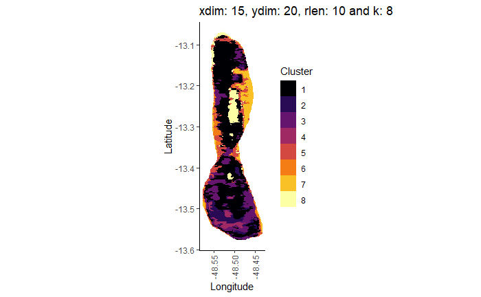

```r
registerDoParallel(cores = parallel::detectCores()-1)
foreach(xdim = xdim) %do% {
  foreach(ydim = ydim) %do% {
    foreach(rlen = rlen) %do% {
      training_som(xdim = xdim,ydim = ydim,rlen = rlen)

    }
  }
}
```

Training Selected Model

```r
# ## Defining the configuration of Neurons
som_grid <- kohonen::somgrid(xdim = 24,ydim = 32,
                             topo = 'hexagonal',
                             toroidal = TRUE,
                             neighbourhood.fct = 'gaussian')
# ## Training Kohonen Maps
set.seed(0)
som_model <-
  kohonen::som(data_train,
                                      grid = som_grid,
                                      rlen = 300,
                                      keep.data = TRUE)

summary(som_model) # Summary
```

```
SOM of size 24x32 with a hexagonaltoroidal topology and a gaussian neighbourhood function.
The number of data layers is 1.
Distance measure(s) used: sumofsquares.
Training data included: 29675 objects.
Mean distance to the closest unit in the map: 0.002.
```

View changes during different epochs for SOM model

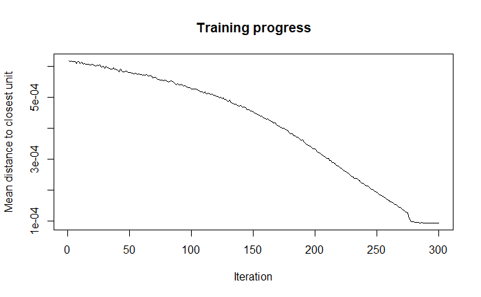

```r
plot(som_model, type = 'changes') # Average distance of neurons by epochs
```

Hierarchical Clustering

```r
dist_mat <- dist(mydata,method = 'euclidean') # Building distance matrix with euclidean distances
```

[output not shown]

Plotting the Dendogram

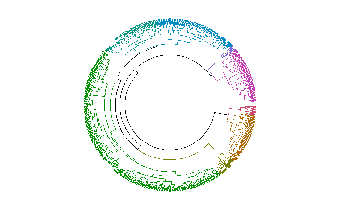

```r
avg_dend_obj <- as.dendrogram(hclust_avg)

avg_col_dend <- color_branches(avg_dend_obj,h=.325)

circlize_dendrogram(avg_col_dend,
                    labels_track_height = NA,
                    dend_track_height = 0.5,labels = FALSE)
```

Plotting the Dissimilarity Matrix

```r
pheatmap(as.matrix(dist_mat),
         clustering_distance_rows = dist_mat,
         clustering_distance_cols = dist_mat,
         show_rownames = FALSE,
         show_colnames = FALSE)
```

[output not shown]

Clustered Kohonen Maps for each feature

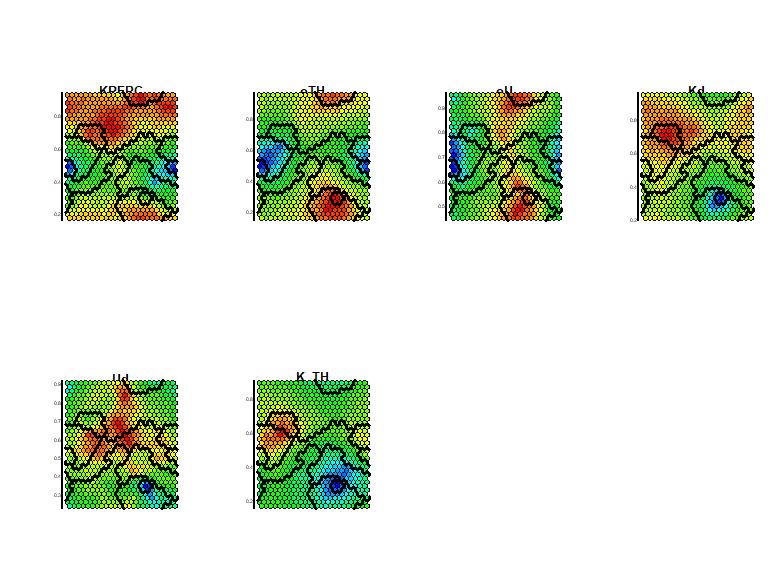

```r
nome <- c('KPERC','eTH','eU','Kd','Ud','K_TH')

par(mfrow=c(2,4), mai = c(5, 5, 5, 5)
)
for (j in 1:6){
  plot(som_model,type="property",
       shape = 'straight',
       property = getCodes(som_model)[,j],
       palette.name=coolBlueHotRed,
       main=nome[j],
       cex=0.5)
  add.cluster.boundaries(som_model, lwd = 3,
                         cut_avg)
}
par(mfrow=c(1,1))
```

```r
NA
NA
```

Distance plot for Kohonen Maps

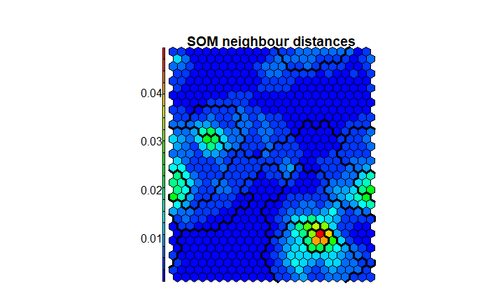

```r
plot(som_model, type="dist.neighbours",
     main = "SOM neighbour distances",
     palette.name=coolBlueHotRed, shape = 'straight'
)
add.cluster.boundaries(som_model, lwd = 3,
                       cut_avg)
```

Map of Clustered Serra Dourada Granite

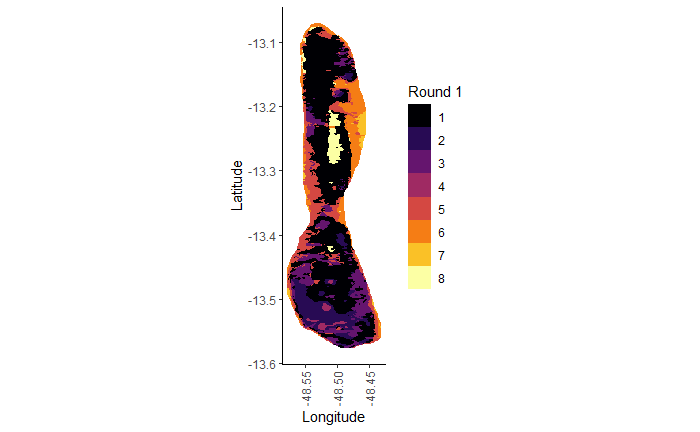

```r
# DATA VIS ----
## Mapa de Cluster
ggplot(df, aes(x = Longitude,
               y = Latitude,
               fill = as.factor(hc_avg))) +
  geom_raster() +
  coord_equal() +
  scale_fill_viridis_d(option = 'B') +
  theme_classic() +
  labs(fill = 'Round 1') +
  theme(axis.text.x = element_text(angle = 90,
                                   vjust = .5))
```

Radar plot for each Cluster

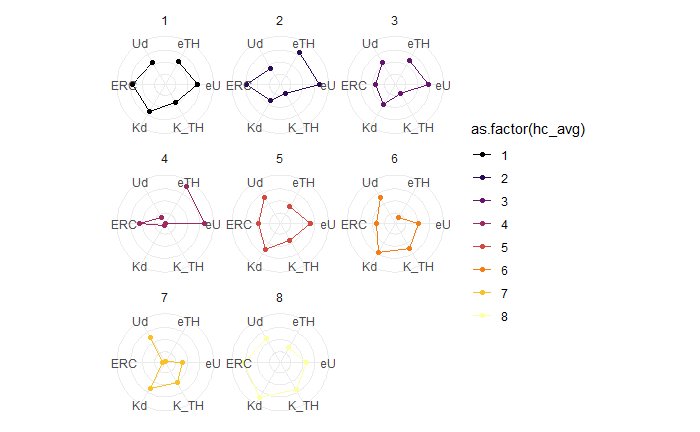

```r
df %>%
  group_by(hc_avg) %>%
  summarize(KPERC = median(K),
            eTH = median(eTH),
            eU = median(eU),
            Kd = median(Kd),
            Ud = median(Ud),
            K_TH = median(K_TH)) %>%
  ungroup() %>%
  gather(value = "value", key = 'key',2:7) %>%
  ggplot(aes(x = key, y = value, col = as.factor(hc_avg),
             group = hc_avg)) +
  geom_line() +
  geom_point() +
  coord_radar() +
  scale_color_viridis_d(option = 'B') +
  scale_fill_viridis_d(option = 'B') +
  theme_minimal() +
  theme(axis.title.x = element_blank(),
        axis.title.y = element_blank(),
        axis.text.y = element_blank()) +
  facet_wrap(. ~ hc_avg)
```